# Simulation_S1

Ziyi Wang

2026-06-09

## Overview

This document reproduces the Supplementary Simulation S1, which is based on the one-sided z-statistic setting with one-dimensional X as the side covariate (auxiliary information).

**Working directory:** Knit this file from (`chai_project/scripts/`).

## 1. Install Dependencies

Run once in a fresh R session before knitting:

```r
# CRAN + Bioconductor + GitHub dependencies
source("install_packages.R")

# chai package (not on CRAN)
remotes::install_github("ziyiwang726/chai")
```

## 2. Load Packages

```r
suppressPackageStartupMessages({
  library(chai)
  library(knitr)
  library(mvtnorm)
  library(mixtools)
  library(KScorrect)
  library(adaptMT)
  library(AdaPTGMM)
  library(splines2)
  library(dplyr)
  library(ggplot2)
  library(tidyr)
  library(coin)
  library(ggrepel)
  library(IHW)
  library(FDRreg)
  library(OrderShapeEM)
  library(patchwork)
  library(ggrepel)
  library(stringr)
})
```

## 3. Simulation generating and fit the models

**Note:**

This chunk may be very time-consuming. Specifically, for each seed (100 randomly generated seeds in total) and each value of $a$ ($a \in {0, 0.5, 1, 1.5, 2}$), one simulation dataset was generated and then analyzed using and each benchmark method. For every method, we recorded the number of selections, FDP, and power at all $q$-level from 0.01 to 0.10, together with the corresponding seed.

By default, the code reads the previously generated RDS file to save time. If you want to re-generate the results from scratch, you can change the path of `cache_file` to let R cannot find the corresponding RDS file so that R starts by re-running the simulation.

```r
set.seed(1)
seeds <- c(sample(1:10000, 99), 123)  # Add seed 123 for checking purpose

n  <- 1000
n0 <- 950
n1 <- 25
m0 <- -0.5; m1 <- 3; m2 <- 5
sd0 <- 1;   sd1 <- 1; sd2 <- 1

# Ground truth for alternative
gt <- seq((n0 + 1), n)

# informativeness grid：from 'no info' to 'higher info'
a_grid <- c(0, 0.5, 1, 1.5, 2)

q_grid <- seq(0.01, 0.1, by = 0.01)
alphas  <- q_grid

# paratmeters for Adapt
formula <- paste0("ns(X, df = ", 2:8, ")")

results_list <- list()

cache_file <- "../data/chai_env/Simulation_S1_results.rds"

if (file.exists(cache_file)) {
  # if already did, load it
  results_s1 <- readRDS(cache_file)
} else {
  # if not, run the simulation
  for (s in seq_along(seeds)) {
    set.seed(seeds[s])

    ## Fix the z
    z0 <- rnorm(n0, mean = 0, sd = 1)
    z1 <- rnorm(n1, mean = 2, sd = 0.5)
    z2 <- rnorm(n1, mean = 3, sd = 0.5)
    z  <- c(z0, z1, z2)
    p <- 1 - pnorm(z)  # One-sided

    ## X
    m0 <- -0.5; m1 <- 3; m2 <- 5
    sd0 <- 1;   sd1 <- 1; sd2 <- 1

    for (a in a_grid) {
      message("Running seed ", s, "/", length(seeds),
        "  (seed value =", seeds[s], ")",
        "  Current a value =", a_val)
      m0a <- m0
      m1a <- m0 + a * (m1 - m0)
      m2a <- m0 + a * (m2 - m0)

      x0 <- rnorm(n0, mean = m0a, sd = sd0)
      x1 <- rnorm(n1, mean = m1a, sd = sd1)
      x2 <- rnorm(n1, mean = m2a, sd = sd2)
      X  <- c(x0, x1, x2)
      x_df <- data.frame(X = X)

      perf_a <- data.frame(
        Seed = integer(),
        a    = numeric(),
        q    = numeric(),
        Method   = character(),
        Selected = numeric(),
        FDP      = numeric(),
        Power    = numeric(),
        stringsAsFactors = FALSE
      )

      # ------------------------------------------------------------------
      # 1. chai
      # ------------------------------------------------------------------
      set.seed(seeds[s])
      res_chai <- chai(z, X, B = 100)

      for (qq in seq_along(q_grid)) {
        select <- clfdrselect(res_chai, q = q_grid[qq])
        p1  <- performance(gt, select, z = res_chai$z,
                           bh_level = q_grid[qq], one.sided = TRUE)
        # chai
        perf_a[nrow(perf_a)+1,] <- list(seeds[s], a, q_grid[qq], "chai", p1[[4]], p1[[1]], p1[[2]])
        # BH
        perf_a[nrow(perf_a)+1,] <- list(seeds[s], a, q_grid[qq], "BH",   p1[[13]], p1[[8]], p1[[9]])
      }


      # ------------------------------------------------------------------
      # 2. adapt_gmm (z)
      # ------------------------------------------------------------------
      set.seed(seeds[s])
      res_gmm_z <- adapt_gmm(x_df, z = z, alphas = alphas,
                             beta_formulas = formula, testing = "one_sided")

      for (qq in seq_along(q_grid)) {
        # idx <- match(qq, alphas)  # 0.05 -> 5, 0.06 -> 6, ..., 0.10 -> 10
        p2  <- performance(gt, res_gmm_z$rejs[[qq]], z = z,
                           bh_level = q_grid[qq], one.sided = TRUE)
        perf_a[nrow(perf_a)+1,] <- list(seeds[s], a, q_grid[qq], "adapt_gmm_z", p2[[4]], p2[[1]], p2[[2]])
      }

      # ------------------------------------------------------------------
      # 3. adapt_gmm (p)
      # ------------------------------------------------------------------
      set.seed(seeds[s])
      res_gmm_p <- adapt_gmm(x_df, pvals = p, alphas = alphas,
                             beta_formulas = formula, testing = "one_sided")
      for (qq in seq_along(q_grid)) {
        # idx <- match(qq, alphas)
        p3  <- performance(gt, res_gmm_p$rejs[[qq]], z = z,
                           bh_level = q_grid[qq], one.sided = TRUE)
        perf_a[nrow(perf_a)+1,] <- list(seeds[s], a, q_grid[qq], "adapt_gmm_p", p3[[4]], p3[[1]], p3[[2]])
      }

      # ------------------------------------------------------------------
      # 4. adapt_glm
      # ------------------------------------------------------------------
      set.seed(seeds[s])
      res_glm <- adapt_glm(x_df, pvals = p, alphas = alphas,
                           pi_formulas = formula, mu_formulas = formula)
      empty <- is.null(res_glm) || (!is.list(res_glm$rejs))
      for (qq in seq_along(q_grid)) {
        if (!empty && lengths(res_glm$rejs)[qq] > 0L){
         p4 <- performance(gt, res_glm$rejs[[qq]], z = z,
                            bh_level = q_grid[qq], one.sided = TRUE)
         perf_a[nrow(perf_a)+1,] <- list(seeds[s], a, q_grid[qq], "adapt_glm", p4[[4]], p4[[1]], p4[[2]])

        } else {
          perf_a[nrow(perf_a)+1,] <- list(seeds[s], a, q_grid[qq], "adapt_glm", 0, 0, 0)
        }
      }

      # ------------------------------------------------------------------
      # 5. OrderShapeEM
      # ------------------------------------------------------------------
      set.seed(seeds[s])
      res_osem <- NULL

      res_osem <- tryCatch(
        OrderShapeEM(pvals = p, order.var = X,
                     OrderShapeEM.control(trace = FALSE)),
        error = function(e) {
          message(paste("OrderShapeEM failed at seed", seeds[s], "a =", a_val, ":", e$message))
          NULL
        }
      )

      if (!is.null(res_osem)) {
        for (qq in seq_along(q_grid)) {
          p5 <- performance(gt, which(res_osem$fdr <= q_grid[qq]), z = z,
                            bh_level = q_grid[qq], one.sided = FALSE)
          perf_a[nrow(perf_a) + 1, ] <- list(seeds[s], a_val, q_grid[qq], "OrderShapeEM",
                                         p5[[4]], p5[[1]], p5[[2]])
        }
      } else {
        for (qq in seq_along(q_grid)) {
          perf_a[nrow(perf_a) + 1, ] <- list(seeds[s], a_val, q_grid[qq], "OrderShapeEM",
                                         NA, NA, NA)
        }
      }


      # ------------------------------------------------------------------
      # 6. FDRreg (theoretical null)
      # ------------------------------------------------------------------
      set.seed(seeds[s])
      res_fdrreg <- FDRreg(z, as.matrix(X), nulltype = "theoretical")
      for (qq in seq_along(q_grid)) {
        p6 <- performance(gt, which(res_fdrreg$FDR <= q_grid[qq]), z = z,
                          bh_level = q_grid[qq], one.sided = TRUE)
        perf_a[nrow(perf_a)+1,] <- list(seeds[s], a, q_grid[qq], "FDRreg", p6[[4]], p6[[1]], p6[[2]])
      }

            # ------------------------------------------------------------------
      # 7. IHW
      # ------------------------------------------------------------------
      set.seed(seeds[s])
      res_ihw_list <- vector("list", length(q_grid))

      for (qq in seq_along(q_grid)) {
        res_ihw_list[[qq]] <- tryCatch(
          IHW::ihw(pvalues = p, covariates = x_df[, 1],
                   alpha = q_grid[qq], nbins = 5),
          error = function(e) {
            message(paste("IHW failed at seed", seeds[s], "a =", a_val,
                          "q =", q_grid[qq], ":", e$message))
            NULL
          }
        )
      }

      for (qq in seq_along(q_grid)) {
        if (!is.null(res_ihw_list[[qq]])) {
          p7 <- performance(gt, which(IHW::adj_pvalues(res_ihw_list[[qq]]) <= q_grid[qq]),
                            z = z, bh_level = q_grid[qq], one.sided = FALSE)
          perf_a[nrow(perf_a) + 1, ] <- list(seeds[s], a_val, q_grid[qq], "IHW",
                                         p7[[4]], p7[[1]], p7[[2]])
        } else {
          perf_a[nrow(perf_a) + 1, ] <- list(seeds[s], a_val, q_grid[qq], "IHW",
                                         NA, NA, NA)
        }
      }

      # Collect results for this (seed, a_val) combination
      results_list[[length(results_list) + 1]] <- perf_a

      # Clean up memory
      gc()
    }  # end a_grid loop
  }  # end seeds loop

  # Combine and tidy
  results_s1 <- dplyr::bind_rows(results_list) |>
    dplyr::mutate(
      Selected = as.numeric(Selected),
      FDP      = as.numeric(FDP),
      Power    = as.numeric(Power)
    )

  # Save to disk
  saveRDS(results_s1, cache_file)

}
```

## 4. Calculate the average across 100 repeats.

```r
# Calculate the average of selections, FDP and power.
summary_s1 <- results_s1 %>%
  group_by(Method, q, a) %>%
  summarise(
    mean_Selected = mean(Selected),
    mean_FDP      = mean(FDP),
    mean_Power    = mean(Power),
    .groups = "drop"
  )

# Check the summary results at a = 1 and q = 0.05
summary_s1 %>% filter(a == 1, q == 0.05)
```

```
## # A tibble: 8 × 6
##   Method           q     a mean_Selected mean_FDP mean_Power
##   <chr>        <dbl> <dbl>         <dbl>    <dbl>      <dbl>
## 1 BH            0.05     1          5.73   0.0481     0.108
## 2 FDRreg        0.05     1         27.9    0.0404     0.535
## 3 IHW           0.05     1         25.1    0.0351     0.484
## 4 OrderShapeEM  0.05     1          3.64   0.0938     0.0574
## 5 adapt_glm     0.05     1         47.2    0.0410     0.902
## 6 adapt_gmm_p   0.05     1         46.1    0.0498     0.874
## 7 adapt_gmm_z   0.05     1         46.1    0.0498     0.875
## 8 chai          0.05     1         48.5    0.0315     0.938
```

```r
sim_s1_long <- summary_s1 %>%
  mutate(
    mean_FDP   = ifelse(is.nan(mean_FDP), NA, mean_FDP),
    mean_Power = ifelse(is.nan(mean_Power), NA, mean_Power)
  ) %>%
  pivot_longer(cols = c(mean_FDP, mean_Power),
               names_to = "Metric", values_to = "Value") %>%
  mutate(Metric = recode(Metric,
                         mean_FDP = "FDP",
                         mean_Power = "Power"))
```

## 5. Main Figure

### 5a. Fix a (Informativeness parameter) - mean FDP across 100 repeats vs. FDR Threshold / mean Power across 100 repeats vs. FDR Threshold

```r
source("consistant_color.R")

a0_dat <- dplyr::filter(sim_s1_long, abs(a - 0) < 1e-12)
a0_fdp <- plot_metric_aq(a0_dat, "FDP", x_var = "q",
                            ylab = "Mean FDP",
                            title = sprintf("FDP vs q (a = 0)"),
                            fdp_y = 0.12,
                            x_breaks = sort(unique(a0_dat$q)))
a0_pow <- plot_metric_aq(a0_dat, "Power", x_var = "q",
                            ylab = "Mean Power",
                            title = sprintf("Power vs q (a = 0)"),
                            x_breaks = sort(unique(a0_dat$q)))

a0.5_dat <- dplyr::filter(sim_s1_long, abs(a - 0.5) < 1e-12)
a0.5_fdp <- plot_metric_aq(a0.5_dat, "FDP", x_var = "q",
                            ylab = "Mean FDP",
                            title = sprintf("FDP vs q (a = 0.5)"),
                            fdp_y = 0.12,
                            x_breaks = sort(unique(a0.5_dat$q)))
a0.5_pow <- plot_metric_aq(a0.5_dat, "Power", x_var = "q",
                            ylab = "Mean Power",
                            title = sprintf("Power vs q (a = 0.5)"),
                            x_breaks = sort(unique(a0.5_dat$q)))

a1_dat <- dplyr::filter(sim_s1_long, abs(a - 1) < 1e-12)
a1_fdp <- plot_metric_aq(a1_dat, "FDP", x_var = "q",
                            ylab = "Mean FDP",
                            title = sprintf("FDP vs q (a = 1)"),
                            fdp_y = 0.12,
                            x_breaks = sort(unique(a1_dat$q)))
a1_pow <- plot_metric_aq(a1_dat, "Power", x_var = "q",
                            ylab = "Mean Power",
                            title = sprintf("Power vs q (a = 1)"),
                            x_breaks = sort(unique(a1_dat$q)))


a1.5_dat <- dplyr::filter(sim_s1_long, abs(a - 1.5) < 1e-12)
a1.5_fdp <- plot_metric_aq(a1.5_dat, "FDP", x_var = "q",
                            ylab = "Mean FDP",
                            title = sprintf("FDP vs q (a = 1.5)"),
                            fdp_y = 0.12,
                            x_breaks = sort(unique(a1.5_dat$q)))
a1.5_pow <- plot_metric_aq(a1.5_dat, "Power", x_var = "q",
                            ylab = "Mean Power",
                            title = sprintf("Power vs q (a = 1.5)"),
                            x_breaks = sort(unique(a1.5_dat$q)))

a2_dat <- dplyr::filter(sim_s1_long, abs(a - 2) < 1e-12)
a2_fdp <- plot_metric_aq(a2_dat, "FDP", x_var = "q",
                            ylab = "Mean FDP",
                            title = sprintf("FDP vs q (a = 2)"),
                            fdp_y = 0.12,
                            x_breaks = sort(unique(a2_dat$q)))
a2_pow <- plot_metric_aq(a2_dat, "Power", x_var = "q",
                            ylab = "Mean Power",
                            title = sprintf("Power vs q (a = 2)"),
                            x_breaks = sort(unique(a2_dat$q)))


fdps  <- list(a0_fdp, a0.5_fdp, a1_fdp, a1.5_fdp, a2_fdp)
pows  <- list(a0_pow, a0.5_pow, a1_pow, a1.5_pow, a2_pow)

combo <- wrap_plots(
  c(fdps, pows),
  nrow = 5, ncol = 2,
  byrow = FALSE
)
```

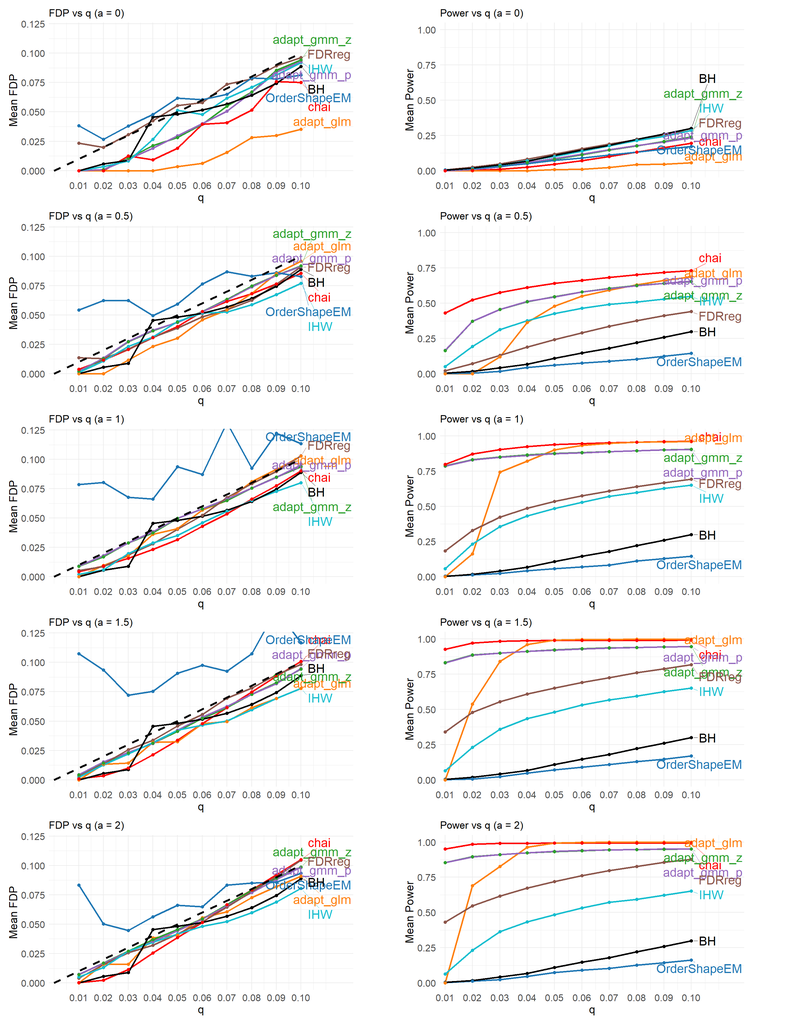

```r
combo
```

```r
# ggsave(
#   filename = "../figures/Sim_S1_fixa.png",
#   plot = combo,
#   width = 14,
#   height = 18,
#   dpi = 300
# )
```

### 5b. Fix q (FDR Threshold) - mean FDP across 100 repeats vs. Informativeness parameter a / mean Power across 100 repeats vs. Informativeness parameter a

```r
q0.01_dat <- dplyr::filter(sim_s1_long, abs(q - 0.01) < 1e-12)
q0.01_fdp <- plot_metric_aq(q0.01_dat, "FDP", x_var = "a",
                            ylab = "Mean FDP",
                            title = sprintf("FDP vs a (q = 0.01)"),
                            fdp_y = 0.15,
                            x_breaks = sort(unique(q0.01_dat$a)),
                            q_level = 0.01)

q0.01_pow <- plot_metric_aq(q0.01_dat, "Power", x_var = "a",
                            ylab = "Mean Power",
                            title = sprintf("Power vs a (q = 0.01)"),
                            x_breaks = sort(unique(q0.01_dat$a)),
                            q_level = 0.01)


q0.05_dat <- dplyr::filter(sim_s1_long, abs(q - 0.05) < 1e-12)
q0.05_fdp <- plot_metric_aq(q0.05_dat, "FDP", x_var = "a",
                            ylab = "Mean FDP",
                            title = sprintf("FDP vs a (q = 0.05)"),
                            fdp_y = 0.15,
                            x_breaks = sort(unique(q0.05_dat$a)),
                            q_level = 0.05)

q0.05_pow <- plot_metric_aq(q0.05_dat, "Power", x_var = "a",
                            ylab = "Mean Power",
                            title = sprintf("Power vs a (q = 0.05)"),
                            x_breaks = sort(unique(q0.05_dat$a)),
                            q_level = 0.05)



q0.1_dat <- dplyr::filter(sim_s1_long, abs(q - 0.1) < 1e-12)
q0.1_fdp <- plot_metric_aq(q0.1_dat, "FDP", x_var = "a",
                            ylab = "Mean FDP",
                            title = sprintf("FDP vs a (q = 0.1)"),
                            fdp_y = 0.15,
                            x_breaks = sort(unique(q0.1_dat$a)),
                            q_level = 0.1)

q0.1_pow <- plot_metric_aq(q0.1_dat, "Power", x_var = "a",
                            ylab = "Mean Power",
                            title = sprintf("Power vs a (q = 0.1)"),
                            x_breaks = sort(unique(q0.1_dat$a)),
                            q_level = 0.1)



fdps_pow  <- list(q0.01_fdp, q0.05_fdp, q0.1_fdp)
pows_pow  <- list(q0.01_pow, q0.05_pow, q0.1_pow)

combo_q <- wrap_plots(
  c(fdps_pow, pows_pow),
  nrow = 3, ncol = 2,
  byrow = FALSE
)
```

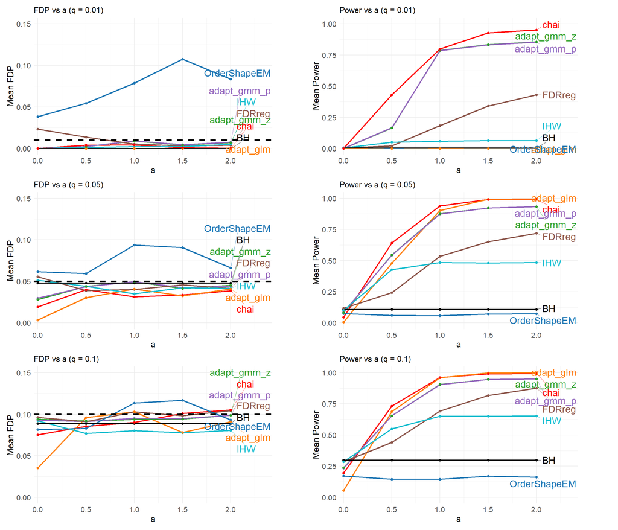

```r
combo_q
```

```r
# ggsave(
#   filename = "../figures/Sim_S1_fixq.png",
#   plot = combo_q,
#   width = 14,
#   height = 12,
#   dpi = 300
# )
```